# Module 7 - Logistic Regression

## Perform some type of variable selection procedure to determine which variables to include in the model. Hint: You will need to specify the “family” argument. Hint 2: If you use cross-validation, the response variable should *not* be a factor for this function to work.

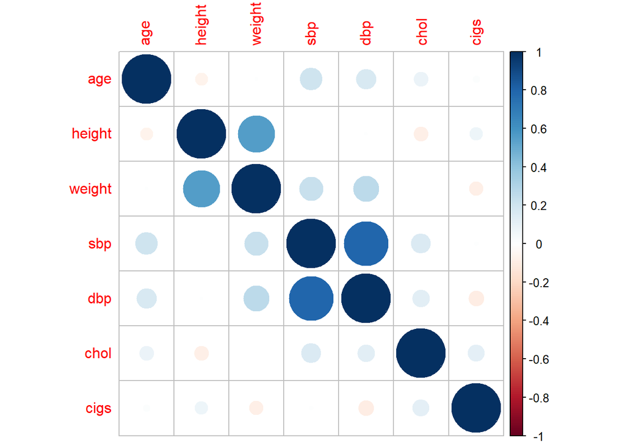

```r
# Does there appear to be multicollinearity based on the correlation plot?
corrplot(cor(heart[,-8]))
```

```r
# For illustration, we will use best subsets (exhaustive) with the BIC metric
heart_best_subsets_bic <- bestglm(as.data.frame(heart),
                                  IC = "BIC",
                                  method = "exhaustive",
                                  TopModels = 1,
                                  family = binomial)
```

```
Morgan-Tatar search since family is non-gaussian.
```

```r
summary(heart_best_subsets_bic$BestModel)
```

```
Call:
glm(formula = y ~ ., family = family, data = Xi, weights = weights)

Coefficients:
              Estimate Std. Error z value Pr(>|z|)
(Intercept) -12.662204   1.281353  -9.882  < 2e-16 ***
age           0.066821   0.015481   4.316 1.59e-05 ***
weight        0.014125   0.004074   3.467 0.000527 ***
sbp           0.021670   0.005566   3.893 9.89e-05 ***
chol          0.013621   0.002089   6.520 7.05e-11 ***
cigs          0.026051   0.005578   4.671 3.00e-06 ***
---
Signif. codes:  0 '***' 0.001 '**' 0.01 '*' 0.05 '.' 0.1 ' ' 1

(Dispersion parameter for binomial family taken to be 1)

    Null deviance: 970.02  on 756  degrees of freedom
Residual deviance: 824.88  on 751  degrees of freedom
AIC: 836.88

Number of Fisher Scoring iterations: 4
```

```r
library(glmnet)  # for ridge, lasso, and elastic net
set.seed(12345)  # make sure to set your seed when doing cross validation!

heart$chd_num <- ifelse(heart$chd == "yes", 1, 0)

env_x <- as.matrix(heart[, 1:7])
env_y <- heart$chd_num
# use cross validation to pick the "best" (based on MSE) lambda
env_lasso_cv <- cv.glmnet(x = env_x,
                          y = env_y,
                          family = "binomial",
                          type.measure = "mse",
                          alpha = 1)  # 1 is code for "LASSO"
coef(env_lasso_cv, s = "lambda.min")
```

```
8 x 1 sparse Matrix of class "dgCMatrix"
                      s1
(Intercept) -10.99923956
age           0.05712279
height        .
weight        0.01127233
sbp           0.01943193
dbp           .
chol          0.01212012
cigs          0.02206304
```

## Use the `glm` function to fit a logistic regression model using the variables identified above. Note that you will need to include the following argument to the `glm` function to indicate you are performing logistic regression: `family = binomial(link = "logit")`.

```r
heart_logistic <- glm(chd ~ age + weight + sbp + chol + cigs,
                      data = heart,
                      family = binomial(link = "logit"))
summary(heart_logistic)
```

```
Call:
glm(formula = chd ~ age + weight + sbp + chol + cigs, family = binomial(link = "logit"),
    data = heart)

Coefficients:
              Estimate Std. Error z value Pr(>|z|)
(Intercept) -12.662204   1.281353  -9.882  < 2e-16 ***
age           0.066821   0.015481   4.316 1.59e-05 ***
weight        0.014125   0.004074   3.467 0.000527 ***
sbp           0.021670   0.005566   3.893 9.89e-05 ***
chol          0.013621   0.002089   6.520 7.05e-11 ***
cigs          0.026051   0.005578   4.671 3.00e-06 ***
---
Signif. codes:  0 '***' 0.001 '**' 0.01 '*' 0.05 '.' 0.1 ' ' 1

(Dispersion parameter for binomial family taken to be 1)

    Null deviance: 970.02  on 756  degrees of freedom
Residual deviance: 824.88  on 751  degrees of freedom
AIC: 836.88

Number of Fisher Scoring iterations: 4
```

## Briefly, check the logistic regression model assumption: The x’s vs log odds are linear (monotone in probability)

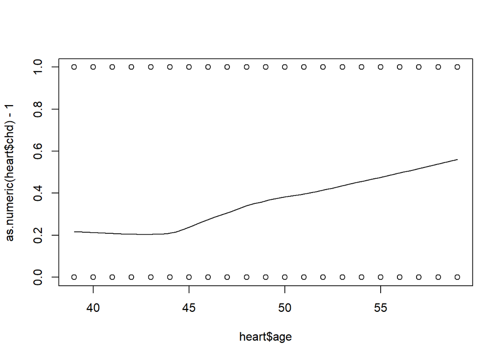

```r
# here is the plot for age - repeat for the other predictors
scatter.smooth(x = heart$age, y = as.numeric(heart$chd) - 1)
```

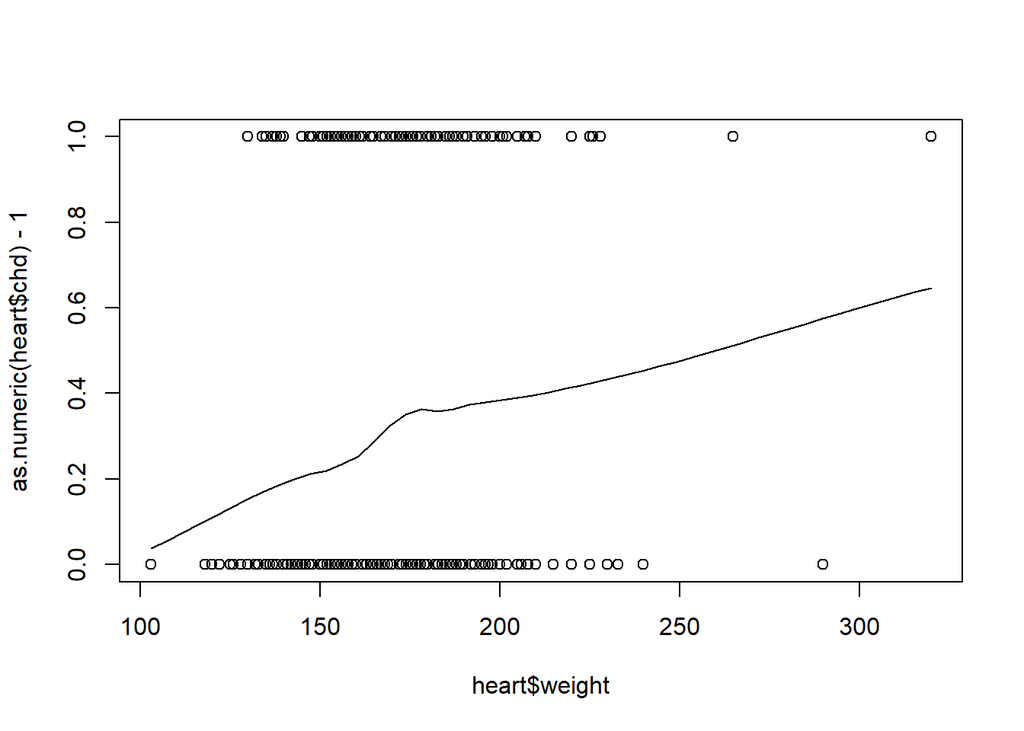

```r
scatter.smooth(x = heart$weight, y = as.numeric(heart$chd) - 1)
```

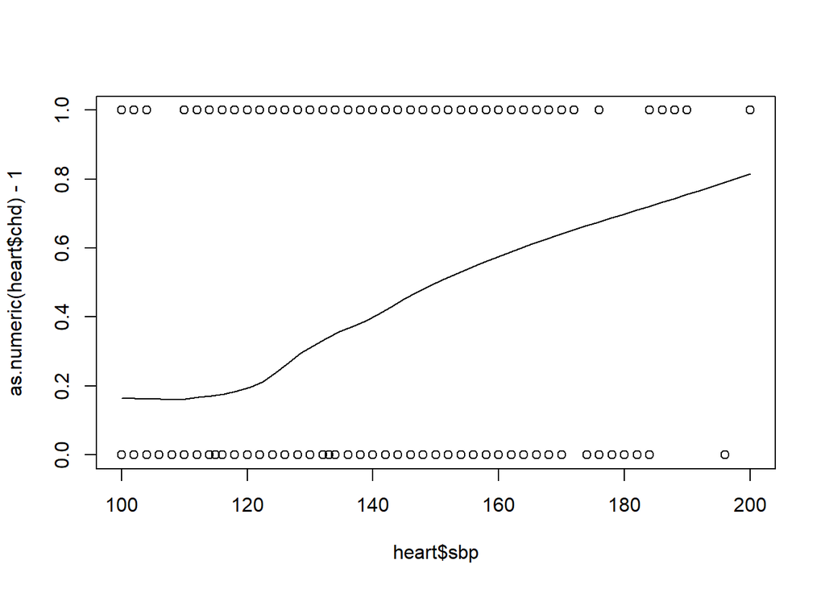

```r
scatter.smooth(x = heart$sbp, y = as.numeric(heart$chd) - 1)
```

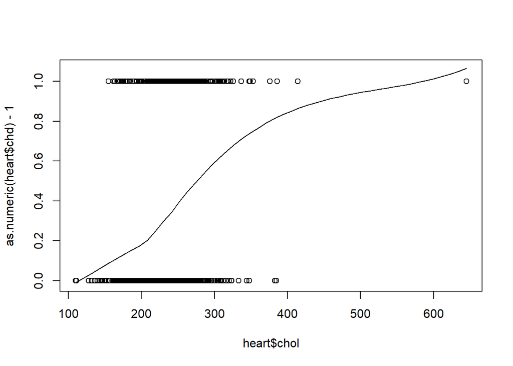

```r
scatter.smooth(x = heart$chol, y = as.numeric(heart$chd) - 1)
```

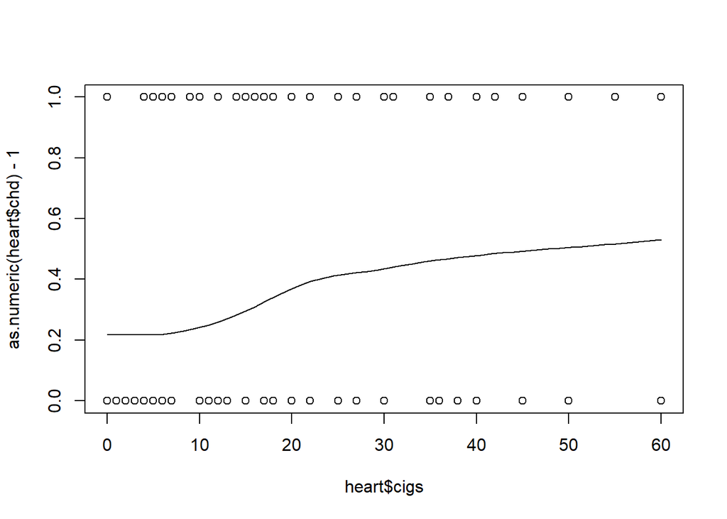

```r
scatter.smooth(x = heart$cigs, y = as.numeric(heart$chd) - 1)
```

## Briefly, check the logistic regression model assumption: No multicollinearity, using the VIFs

```r
# this code uses the pseudo R-Squared
vif(heart_logistic)
```

```
     age   weight      sbp     chol     cigs
1.032184 1.064640 1.064431 1.015856 1.021987
```

```r
# this code uses the real R-Squared (and is valid since we are looking at how
# the predictor variables relate, and we are not using the response)
heart_lm <- lm(as.numeric(chd) ~ age + weight + sbp + chol + cigs,
               data = heart)
vif(heart_lm)
```

```
     age   weight      sbp     chol     cigs
1.046997 1.064187 1.124682 1.042604 1.020812
```

```r
max(vif(heart_lm))# < 10
```

```
[1] 1.124682
```

```r
mean(vif(heart_lm)) # < 5
```

```
[1] 1.059856
```

## Briefly, check the logistic regression model assumption: No influential observations

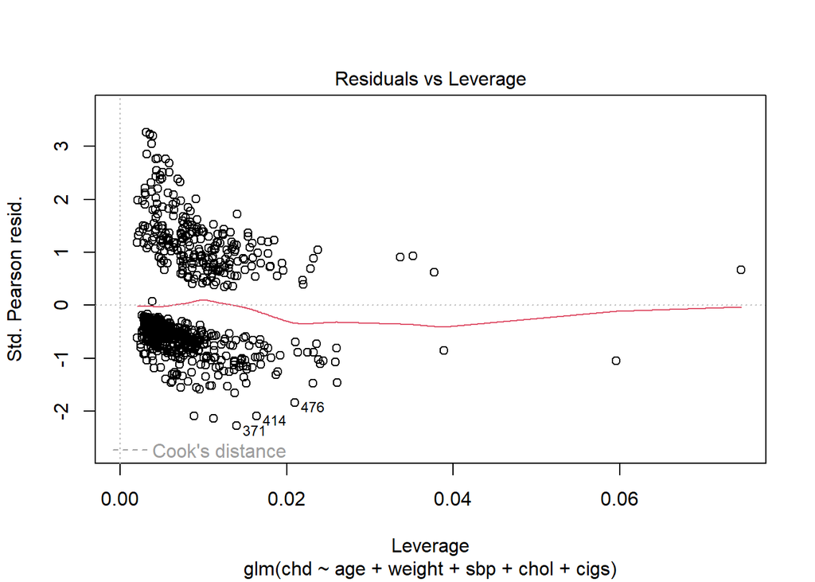

```r
plot(heart_logistic, which = 5, cook.levels = .5) # Residuals by leverage
```

## Create confidence intervals for $\beta_k$, $\exp\{\beta_k\}$, and $100 \times (\exp\{\beta_k\} - 1)%$ for all predictors using the `confint` function. Make sure the confidence intervals for age match the ones in the notes and that you can interpret the intervals correctly.

```r
heart_conf_int_LOR <- confint(heart_logistic)[-1,] # omit intercept row
# A
heart_conf_int_LOR
```

```
             2.5 %     97.5 %
age    0.036653318 0.09740894
weight 0.006220309 0.02224086
sbp    0.010831848 0.03269304
chol   0.009600158 0.01779817
cigs   0.015179767 0.03707339
```

```r
# B
exp(heart_conf_int_LOR)
```

```
          2.5 %   97.5 %
age    1.037333 1.102311
weight 1.006240 1.022490
sbp    1.010891 1.033233
chol   1.009646 1.017958
cigs   1.015296 1.037769
```

```r
# C
100 * (exp(heart_conf_int_LOR) - 1) # Most straigtforward
```

```
           2.5 %    97.5 %
age    3.7333334 10.231106
weight 0.6239696  2.249003
sbp    1.0890724  3.323333
chol   0.9646387  1.795750
cigs   1.5295565  3.776918
```

## Calculate the predicted probability that a patient has CHD using the `predict` function for a patient where age = 50, weight = 182, sbp = 136, chol = 253, and cigs = 20.

```r
new_patient <- data.frame(age = 50,
                          weight = 182,
                          sbp = 136,
                          chol = 253,
                          cigs = 20)
# predicted log odds
pred_log_odds <- predict(heart_logistic,
                         newdata = new_patient)

pred_log_odds

# predicted probability

exp(pred_log_odds)/(1 + exp(pred_log_odds))


# can do this two-step process in one step by using type = "response" to get the
# predicted probability

pred_prob <- predict(heart_logistic,
                         newdata = new_patient,
                     type = "response")

pred_prob
```

[output not shown]

## Calculate a 95% confidence interval for the predicted probability that a patient has CHD for a patient where age = 50, weight = 182, sbp = 136, chol = 253, and cigs = 20.

```r
new_patient <- data.frame(age = 50,
                          weight = 182,
                          sbp = 136,
                          chol = 253,
                          cigs = 20)

# get the log odds ratio with the standard error

log_odds <- predict(heart_logistic,
                    newdata = new_patient,
                    se.fit = TRUE)

# compute the margin of error

moe <- qnorm(p = .975, lower.tail = TRUE) * log_odds$se.fit
moe
```

```
[1] 0.2218135
```

```r
# compute the 95% confidence interval (and point estimate) for the log odds

pred_interval <- log_odds$fit + c(-1, 0, 1) * moe

# compute the 95% confidence interval (and point estimate) for the predicted
# probability

exp(pred_interval) / (1 + exp(pred_interval))
```

```
[1] 0.4855135 0.5408715 0.5952387
```

## Check the logistic regression model performance

### Compute the likelihood ratio test statistic (aka the deviance, aka the model chi-squared test) and its corresponding p-value. Hint: use the deviances reported in the logistic regression model output for the test statistic, and use the `pchisq` function for the p-value.

```r
# Likelihood ratio test statistic
like_ratio <- heart_logistic$null.deviance - heart_logistic$deviance

# Likelihood ratio p-value
pchisq(q = like_ratio,
       df = length(coef(heart_logistic)) - 1,
       lower.tail = FALSE)
```

```
[1] 1.444019e-29
```

### Compute the Pseudo R-Squared. Hint: use the deviances reported in the logistic regression model output.

```r
1 - heart_logistic$deviance/heart_logistic$null.deviance
```

```
[1] 0.1496259
```

### Find the best cutoff value for classification by minimizing the percent misclassified (c in the notes).

```r
# get the predicted probabilities for all 757 patients:
heart_preds <- predict(heart_logistic,
                       type = "response")

# Look at the first few predictions:

head(heart_preds)
```

```
         1          2          3          4          5          6
0.62571005 0.68725502 0.20357437 0.75961211 0.47259570 0.08774389
```

```r
# create a sequence from 0 to 1 to represent all possible cut-off values (c)
# that we could choose:

possible_cutoffs <- seq(0, 1, by = .01)


# transform heart$chd from a factor with levels "yes" and "no" to a numeric of
# 1's and 0's:

heart_binary <- ifelse(heart$chd == "yes", 1, 0)
heart_binary
```

[output not shown]

```r
# create an empty vector where we will store the percent misclassified for each
# possible cut-off value we created:

percent_missclass <- rep(NA, length(possible_cutoffs))


# for each possible cut-off value, (1) grab the cut-off value, (2) for all 757
# patients, store a 1 in "classify" if their predicted probability is larger
# than the cut-off value, and (3) compute the average percent misclassified
# across the 757 patients when using that cut-off by averaging the number of
# times "classify" (0 or 1 based on how that cut-off classified a person) is
# not the same as heart_binary (the truth):

for(i in 1:length(possible_cutoffs)){
  classify <- ifelse(heart_preds > possible_cutoffs[i], 1, 0)
  percent_missclass[i] <- mean(classify != heart_binary)
}


# percent_misclass holds the average misclassification rates for each cut-off
percent_missclass
```

```
  [1] 0.6605020 0.6605020 0.6605020 0.6591810 0.6578600 0.6499339 0.6406869
  [8] 0.6221929 0.6076618 0.5997358 0.5785997 0.5574637 0.5416116 0.5257596
 [15] 0.5099075 0.4966975 0.4782034 0.4597094 0.4398943 0.4319683 0.4187583
 [22] 0.4108322 0.4042272 0.3936592 0.3844122 0.3685601 0.3619551 0.3500661
 [29] 0.3368560 0.3236460 0.3130779 0.3157199 0.3130779 0.3130779 0.3077939
 [36] 0.3091149 0.3064729 0.3025099 0.2972259 0.2959049 0.2932629 0.2919419
 [43] 0.2972259 0.2972259 0.2932629 0.2892999 0.2919419 0.2945839 0.2945839
 [50] 0.2959049 0.2919419 0.2853369 0.2800528 0.2800528 0.2800528 0.2866579
 [57] 0.2879789 0.2906209 0.2906209 0.2892999 0.2932629 0.2945839 0.2998679
 [64] 0.2998679 0.2972259 0.2985469 0.3025099 0.3064729 0.3011889 0.3051519
 [71] 0.3064729 0.3104359 0.3104359 0.3104359 0.3143989 0.3157199 0.3183620
 [78] 0.3196830 0.3236460 0.3262880 0.3276090 0.3289300 0.3249670 0.3262880
 [85] 0.3276090 0.3289300 0.3315720 0.3328930 0.3355350 0.3368560 0.3381770
 [92] 0.3381770 0.3381770 0.3381770 0.3381770 0.3381770 0.3381770 0.3381770
 [99] 0.3381770 0.3381770 0.3394980
```

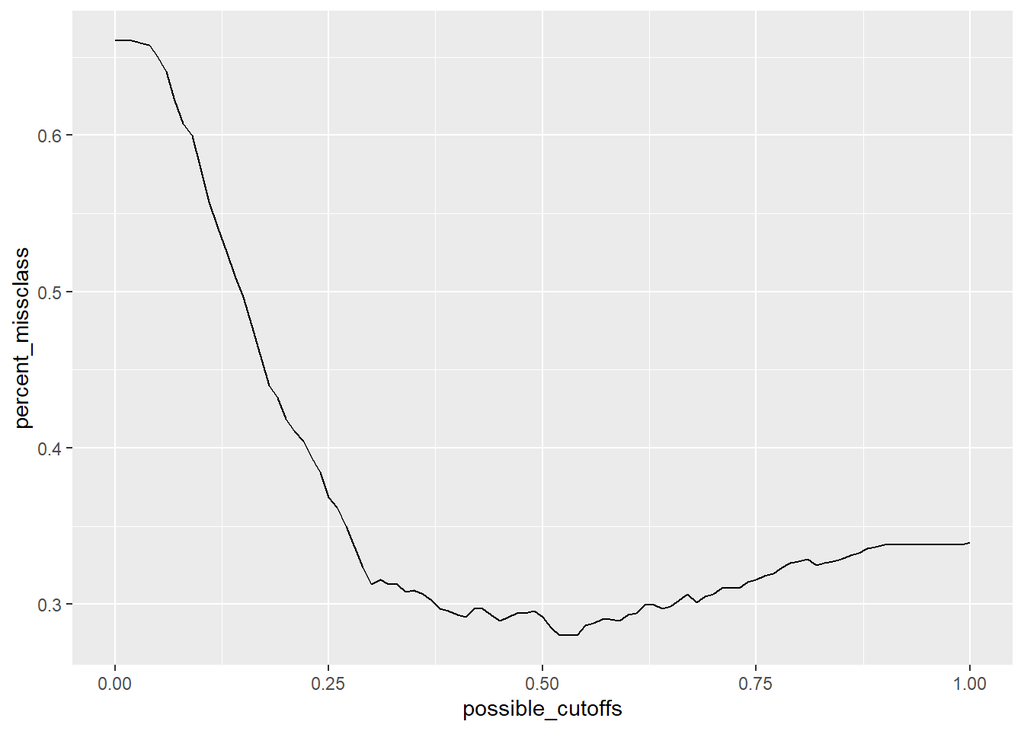

```r
# put this information in a dataframe so we can plot it with ggplot:
missclass_df <- as.data.frame(cbind(percent_missclass, possible_cutoffs))

# plot the misclassification rate against the cut-off value:
ggplot(data = missclass_df) +
  geom_line(aes(x = possible_cutoffs, y = percent_missclass))
```

```r
# choose the "best" cut-off that minimizes the percent misclassified:

cutoff_best <- possible_cutoffs[which.min(percent_missclass)]

percent_missclass == min(percent_missclass) # .53 and .54 also minimize
```

```
  [1] FALSE FALSE FALSE FALSE FALSE FALSE FALSE FALSE FALSE FALSE FALSE FALSE
 [13] FALSE FALSE FALSE FALSE FALSE FALSE FALSE FALSE FALSE FALSE FALSE FALSE
 [25] FALSE FALSE FALSE FALSE FALSE FALSE FALSE FALSE FALSE FALSE FALSE FALSE
 [37] FALSE FALSE FALSE FALSE FALSE FALSE FALSE FALSE FALSE FALSE FALSE FALSE
 [49] FALSE FALSE FALSE FALSE  TRUE  TRUE  TRUE FALSE FALSE FALSE FALSE FALSE
 [61] FALSE FALSE FALSE FALSE FALSE FALSE FALSE FALSE FALSE FALSE FALSE FALSE
 [73] FALSE FALSE FALSE FALSE FALSE FALSE FALSE FALSE FALSE FALSE FALSE FALSE
 [85] FALSE FALSE FALSE FALSE FALSE FALSE FALSE FALSE FALSE FALSE FALSE FALSE
 [97] FALSE FALSE FALSE FALSE FALSE
```

### Create a confusion matrix based on the best cutoff (note that the order is changed in the table created here vs the table in the notes)

```r
# for each of the 757 patients, compare their predicted probability with the
# chosen cut-off value. If their predicted probability is larger than the
# cut-off store "TRUE", otherwise, store "FALSE" in preds

preds <- heart_preds > cutoff_best

# create a confusion matrix with the truth and the predicted classification:

conf_mat <- table("truth" = heart$chd, "predicted" = preds)
conf_mat
```

```
     predicted
truth FALSE TRUE
  no    446   54
  yes   158   99
```

```r
# note that we can also add column and row sums, which is useful for
# calculations:

addmargins(conf_mat)
```

```
     predicted
truth FALSE TRUE Sum
  no    446   54 500
  yes   158   99 257
  Sum   604  153 757
```

### Plot the ROC curve and obtain the AUC

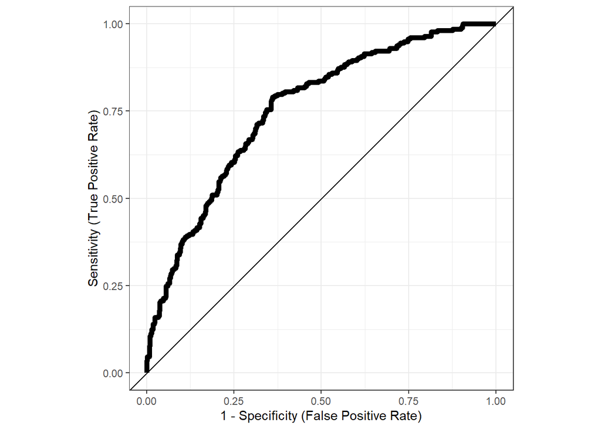

```r
# METHOD 1: using the pROC package
my_roc <- roc(heart$chd, heart_preds)
ggplot() +
  geom_path(mapping = aes(x = 1 - my_roc$specificities,
                          y = my_roc$sensitivities),
            linewidth = 2) +
  geom_abline(slope = 1, intercept = 0) +
  theme_bw() +
  xlab("1 - Specificity (False Positive Rate)") +
  ylab("Sensitivity (True Positive Rate)") +
  theme(aspect.ratio = 1)
```

```r
auc(my_roc)  # AUC
```

```
Area under the curve: 0.7546
```

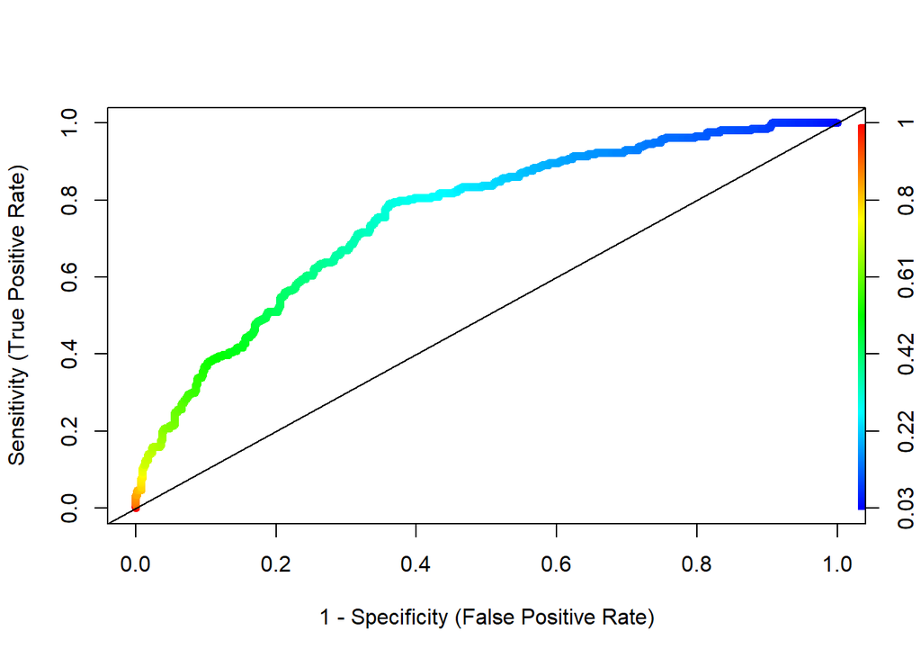

```r
# METHOD 2: using the ROCR package (ROC curve colored based on cutoff value)
pred <- prediction(heart_preds, heart$chd)
perf <- performance(pred, "tpr", "fpr")  # tpr = true positive rate,
# fpr = false positive rate
plot(perf,
     colorize = TRUE,
     lwd = 6,
     xlab = "1 - Specificity (False Positive Rate)",
     ylab = "Sensitivity (True Positive Rate)")
abline(a = 0, b = 1)
```

```r
# AUC
auc <- performance(pred, measure = "auc")
auc@y.values[[1]]
```

```
[1] 0.7545992
```

```r
str(auc)
```

```
Formal class 'performance' [package "ROCR"] with 6 slots
  ..@ x.name      : chr "None"
  ..@ y.name      : chr "Area under the ROC curve"
  ..@ alpha.name  : chr "none"
  ..@ x.values    : list()
  ..@ y.values    :List of 1
  .. ..$ : num 0.755
  ..@ alpha.values: list()
```

## Summary and Conclusions

Logistic regression is used when you have a binary response variable. Many of the things we learned for linear regression apply to logistic regression, but there are several differences. For instance, we have few model assumptions, we measure performance based on deviances (instead of sums of squares), the coefficients are in terms of log odds ratios, and we can perform classification.